# Manipulation de données avec dplyr

## Avant toutes choses

- On crée un projet
- On crée un script
- On charge les données `fruits`

```r
library(dplyr)
data("fruits", package = "minidebuter")
```

## Fruits est un fait un “tibble”

```r
fruits
```

```
#> # A tibble: 51 × 18
#>    nom     groupe Energie   Eau Proteines Glucides Lipides Sucres Fructose
#>    <chr>   <chr>    <dbl> <dbl>     <dbl>    <dbl>   <dbl>  <dbl>    <dbl>
#>  1 Abricot crus       194  87.1      0.81     9.01    0.25    6.7     1.3
#>  2 Abricot secs      1010  24.7      2.88    59.1     0.5    34.3    10.6
#>  3 Ananas  exoti…     304  81.3      0.94    15.1     0.25   14.9     2.8
#>  4 Banane  exoti…     383  75.8      1.06    19.7     0.25   15.6     3.8
#>  5 Canneb… secs      1410  14.6      0.25    76.4     1      72.8    28.4
#>  6 Cerise  crus       235  85.7      0.81    13       0.25   10       4.6
#>  7 Citron  crus       118  91.3      0.25     1.56    0.25    0.8     0.4
#>  8 Clemen… crus       200  87        0.81     9.17    0.25    8.6     1.5
#>  9 Compot… compo…     279  82.9      0.25    15.3     0.08   14.6     6.92
#> 10 Compot… compo…     432  72.9      0.23    24.4     0.21   20.7     7.9
#> # ℹ 41 more rows
#> # ℹ 9 more variables: Fibres <dbl>, Calcium <dbl>, Magnesium <dbl>,
#> #   Phosphore <dbl>, Potassium <dbl>, Zinc <dbl>, BetaCarotene <dbl>,
#> #   VitamineE <dbl>, VitamineC <dbl>
```

```r
class(fruits)
```

```
#> [1] "tbl_df"     "tbl"        "data.frame"
```

## Bref, c’est quoi un `tibble` ?

## Mise à jour de la table des classes d’objets !

| Nom | Appelation officielle | Exemple |
| --- | --- | --- |
| Vecteur | ??? | `1:10` |
| Facteur | `factor` | `gl(2, 2)` |
| Matrice | `matrix` | `matrix(1:4, 2, 2)` |
| Tableau | `data.frame` | `mtcars` |
| Tableau | `tibble` | `fruits` |
| Liste | `list` | `list(a = 1, b = 1:10, c = "Hello!")` |
| Fonction | `function` | `sin`, `exp`, `log` |

## Comment créer une nouvelle colonne ?

Par sécurité : je crée une copie de mes données

```r
fruits2 <- fruits
```

On utilise le plus souvent l’opérateur `$` :

```r
fruits2$Sucres_ratio <- fruits2$Sucres / 100
```

## Le principe de l’ajout de colonne

Sur un tableau `tab`, je souhaite ajouter la colonne `A` :

```
tab$A <- nouvelles_valeurs
```

Attention :

- Si la colonne `A` existe déjà, les valeurs sont écrasée
- Si les nouvelles valeurs ne sont pas de la bonne longueur, elles sont recyclées
- Sans rien dire pour les `data.frame`, avec une erreur pour les `tibble`

## Exemple d’erreur

```r
fruits2$recyclage <- c(0, 1)
```

```
Erreur : Assigned data `c(0, 1)` must be compatible with existing data.
x Existing data has 51 rows.
x Assigned data has 2 rows.
ℹ Only vectors of size 1 are recycled.
Run `rlang::last_error()` to see where the error occurred.
```

## Exemple d’horreur !

```r
mtcars2 <- mtcars
mtcars2$recyclage <- c(0, 1)
mtcars2$recyclage
```

```
#>  [1] 0 1 0 1 0 1 0 1 0 1 0 1 0 1 0 1 0 1 0 1 0 1 0 1 0 1 0 1 0 1 0 1
```

## Le tydiverse

## Enchaîner les commandes avec magrittr

- On utilise un opérateur

`%>%`

- Avant : `f(g(x))`
- Après : `g(x) %>% f()`

[figure not shown]

## Exemple

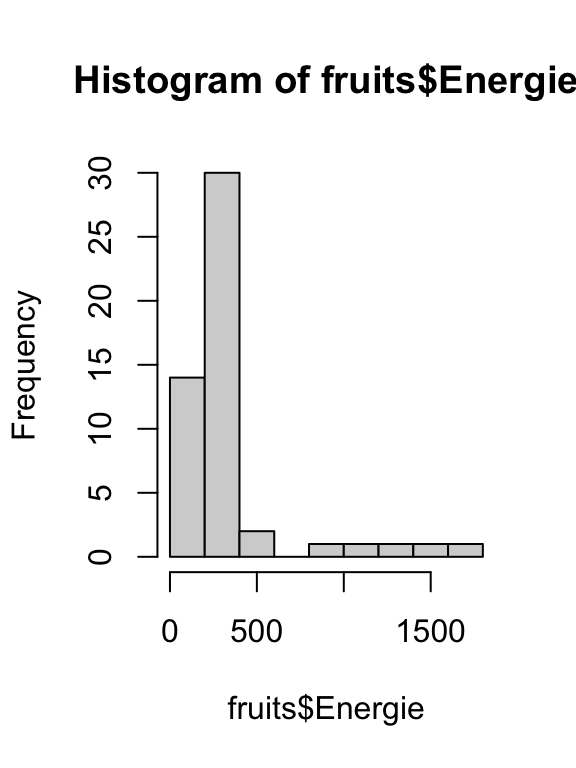

```r
## Histogramme
hist(fruits$Energie)
```

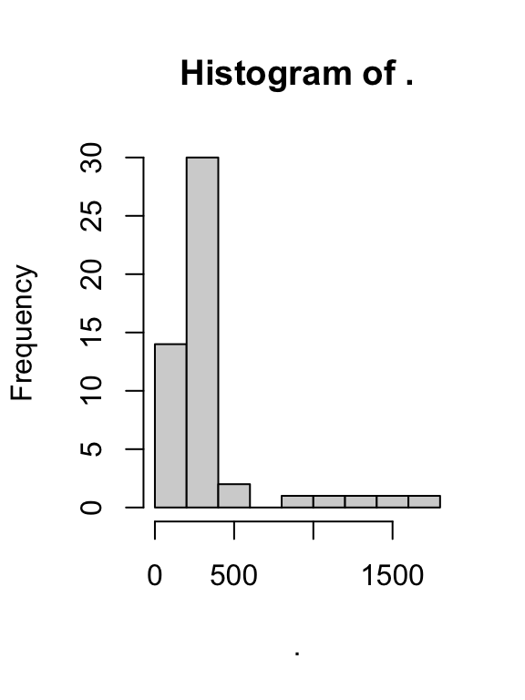

```r
library(magrittr)
fruits$Energie %>% hist()
```

## Le tidyverse

Tidyverse: https://www.tidyverse.org/

[figure not shown]

## Charger les packages

Charger le package `dplyr`…

```r
library(dplyr) # ou require(dplyr)
```

Ou bien charger `tidyverse`…

```r
library(tidyverse)
```

… mais cela chargera d’autres packages en plus

## Le format “tibble”

Les données sont au format “tibble” : c’est comme des “data-frames” mais en mieux !

```r
fruits
```

```
#> # A tibble: 51 × 18
#>    nom     groupe Energie   Eau Proteines Glucides Lipides Sucres Fructose
#>    <chr>   <chr>    <dbl> <dbl>     <dbl>    <dbl>   <dbl>  <dbl>    <dbl>
#>  1 Abricot crus       194  87.1      0.81     9.01    0.25    6.7     1.3
#>  2 Abricot secs      1010  24.7      2.88    59.1     0.5    34.3    10.6
#>  3 Ananas  exoti…     304  81.3      0.94    15.1     0.25   14.9     2.8
#>  4 Banane  exoti…     383  75.8      1.06    19.7     0.25   15.6     3.8
#>  5 Canneb… secs      1410  14.6      0.25    76.4     1      72.8    28.4
#>  6 Cerise  crus       235  85.7      0.81    13       0.25   10       4.6
#>  7 Citron  crus       118  91.3      0.25     1.56    0.25    0.8     0.4
#>  8 Clemen… crus       200  87        0.81     9.17    0.25    8.6     1.5
#>  9 Compot… compo…     279  82.9      0.25    15.3     0.08   14.6     6.92
#> 10 Compot… compo…     432  72.9      0.23    24.4     0.21   20.7     7.9
#> # ℹ 41 more rows
#> # ℹ 9 more variables: Fibres <dbl>, Calcium <dbl>, Magnesium <dbl>,
#> #   Phosphore <dbl>, Potassium <dbl>, Zinc <dbl>, BetaCarotene <dbl>,
#> #   VitamineE <dbl>, VitamineC <dbl>
```

## Les fonctions de dplyr

Nous allons voir ensemble quelques fonctions très pratiques de la librairie `dplyr`.

| # | Fonction (US) | Fonction (UK) | Description |
| --- | --- | --- | --- |
| 1 | `mutate` | `mutate` | Créer ou modifier des colonnes |
| 2 | `select` | `select` | Sélectionner des colonnes |
| 3 | `relocate` | `relocate` | Ré-arranger des colonnes |
| 4 | `arrange` | `arrange` | Trier les lignes |
| 5 | `filter` | `filter` | Sélectionner des lignes |
| 6 | `group_by` | `group_by` | Grouper des lignes |
| 7 | `summarize` | `summarise` | Résumer des groupes |
| 8 | `count` | `count` | Compter |

[figure not shown]

## Créer ou modifier des colonnes

Avec la fonction `mutate`.

```r
fruits2 <- fruits %>%
  mutate(Sucres_ratio = Sucres / 100)

head(fruits2[, "Sucres_ratio"])
```

```
#> # A tibble: 6 × 1
#>   Sucres_ratio
#>          <dbl>
#> 1        0.067
#> 2        0.343
#> 3        0.149
#> 4        0.156
#> 5        0.728
#> 6        0.1
```

Avec les fonctions classiques.

```r
fruits2 <- fruits
fruits2$Sucres_ratio <-
  fruits2$Sucres / 100
head(fruits2[, "Sucres_ratio"])
```

```
#> # A tibble: 6 × 1
#>   Sucres_ratio
#>          <dbl>
#> 1        0.067
#> 2        0.343
#> 3        0.149
#> 4        0.156
#> 5        0.728
#> 6        0.1
```

## Sélectionner des colonnes

Avec la fonction `select`.

```r
fruits %>%
  select(
    Energie,
    Sucres,
    Lipides,
    Proteines)
```

Avec les fonctions classiques.

```r
fruits[,
  c(
    "Energie",
    "Sucres",
    "Lipides",
    "Proteines")]
```

## Sélectionner des colonnes - bis

la fonction `select` est très versatile !

```r
fruits %>%
  select(Energie:Proteines, - Eau)
```

On peut sélectionner des plages entières de colonnes sur la base de leurs noms, en enlever avec le `-`, combiner tout cela avec la fonction `c()`… ou pas !

**Attention, la flexibilité a un coût !**

## Trier des lignes

Avec les fonctions `arrange` et `desc`.

```r
fruits %>%
  select(Energie, Sucres, Fibres) %>%
  arrange(desc(Fibres))
```

```
#> # A tibble: 51 × 3
#>    Energie Sucres Fibres
#>      <dbl>  <dbl>  <dbl>
#>  1    1010  34.3     8.3
#>  2     425   8.5     6.8
#>  3    1410  72.8     5.7
#>  4     198   6.1     5.2
#>  5     969  38.1     5.1
#>  6     289   6.63    4.6
#>  7     206   5.4     4.3
#>  8     170   2.1     4.3
#>  9    1360  70.3     4.2
#> 10     293  12.2     4.1
#> # ℹ 41 more rows
```

Avec les fonctions classiques

```r
fruits[
  order(fruits$Fibres, decreasing = TRUE),
  c("Energie", "Sucres", "Fibres")]
```

```
#> # A tibble: 51 × 3
#>    Energie Sucres Fibres
#>      <dbl>  <dbl>  <dbl>
#>  1    1010  34.3     8.3
#>  2     425   8.5     6.8
#>  3    1410  72.8     5.7
#>  4     198   6.1     5.2
#>  5     969  38.1     5.1
#>  6     289   6.63    4.6
#>  7     206   5.4     4.3
#>  8     170   2.1     4.3
#>  9    1360  70.3     4.2
#> 10     293  12.2     4.1
#> # ℹ 41 more rows
```

## Sélectionner des lignes

Avec la fonction `filter`.

```r
fruits %>%
  filter(Sucres > 60)
```

```
#> # A tibble: 2 × 18
#>   nom      groupe Energie   Eau Proteines Glucides Lipides Sucres Fructose
#>   <chr>    <chr>    <dbl> <dbl>     <dbl>    <dbl>   <dbl>  <dbl>    <dbl>
#> 1 Cannebe… secs      1410  14.6      0.25     76.4     1     72.8     28.4
#> 2 Raisin   secs      1360  16        3        73.2     0.9   70.3     36
#> # ℹ 9 more variables: Fibres <dbl>, Calcium <dbl>, Magnesium <dbl>,
#> #   Phosphore <dbl>, Potassium <dbl>, Zinc <dbl>, BetaCarotene <dbl>,
#> #   VitamineE <dbl>, VitamineC <dbl>
```

Avec les fonctions classiques.

```r
fruits[fruits$Sucres > 60, ]
```

```
#> # A tibble: 2 × 18
#>   nom      groupe Energie   Eau Proteines Glucides Lipides Sucres Fructose
#>   <chr>    <chr>    <dbl> <dbl>     <dbl>    <dbl>   <dbl>  <dbl>    <dbl>
#> 1 Cannebe… secs      1410  14.6      0.25     76.4     1     72.8     28.4
#> 2 Raisin   secs      1360  16        3        73.2     0.9   70.3     36
#> # ℹ 9 more variables: Fibres <dbl>, Calcium <dbl>, Magnesium <dbl>,
#> #   Phosphore <dbl>, Potassium <dbl>, Zinc <dbl>, BetaCarotene <dbl>,
#> #   VitamineE <dbl>, VitamineC <dbl>
```

## Sélectionner des plages de lignes

Avec la fonction `slice`.

```r
fruits %>%
  slice(3:10)
```

```
#> # A tibble: 8 × 18
#>   nom      groupe Energie   Eau Proteines Glucides Lipides Sucres Fructose
#>   <chr>    <chr>    <dbl> <dbl>     <dbl>    <dbl>   <dbl>  <dbl>    <dbl>
#> 1 Ananas   exoti…     304  81.3      0.94    15.1     0.25   14.9     2.8
#> 2 Banane   exoti…     383  75.8      1.06    19.7     0.25   15.6     3.8
#> 3 Cannebe… secs      1410  14.6      0.25    76.4     1      72.8    28.4
#> 4 Cerise   crus       235  85.7      0.81    13       0.25   10       4.6
#> 5 Citron   crus       118  91.3      0.25     1.56    0.25    0.8     0.4
#> 6 Clement… crus       200  87        0.81     9.17    0.25    8.6     1.5
#> 7 Compote… compo…     279  82.9      0.25    15.3     0.08   14.6     6.92
#> 8 Compote… compo…     432  72.9      0.23    24.4     0.21   20.7     7.9
#> # ℹ 9 more variables: Fibres <dbl>, Calcium <dbl>, Magnesium <dbl>,
#> #   Phosphore <dbl>, Potassium <dbl>, Zinc <dbl>, BetaCarotene <dbl>,
#> #   VitamineE <dbl>, VitamineC <dbl>
```

Avec les fonctions classiques.

```r
fruits[3:10, ]
```

```
#> # A tibble: 8 × 18
#>   nom      groupe Energie   Eau Proteines Glucides Lipides Sucres Fructose
#>   <chr>    <chr>    <dbl> <dbl>     <dbl>    <dbl>   <dbl>  <dbl>    <dbl>
#> 1 Ananas   exoti…     304  81.3      0.94    15.1     0.25   14.9     2.8
#> 2 Banane   exoti…     383  75.8      1.06    19.7     0.25   15.6     3.8
#> 3 Cannebe… secs      1410  14.6      0.25    76.4     1      72.8    28.4
#> 4 Cerise   crus       235  85.7      0.81    13       0.25   10       4.6
#> 5 Citron   crus       118  91.3      0.25     1.56    0.25    0.8     0.4
#> 6 Clement… crus       200  87        0.81     9.17    0.25    8.6     1.5
#> 7 Compote… compo…     279  82.9      0.25    15.3     0.08   14.6     6.92
#> 8 Compote… compo…     432  72.9      0.23    24.4     0.21   20.7     7.9
#> # ℹ 9 more variables: Fibres <dbl>, Calcium <dbl>, Magnesium <dbl>,
#> #   Phosphore <dbl>, Potassium <dbl>, Zinc <dbl>, BetaCarotene <dbl>,
#> #   VitamineE <dbl>, VitamineC <dbl>
```

## Grouper des lignes

Avec la fonction `group_by` :

```r
fruits %>% group_by(groupe)
```

```
#> # A tibble: 51 × 18
#> # Groups:   groupe [4]
#>    nom     groupe Energie   Eau Proteines Glucides Lipides Sucres Fructose
#>    <chr>   <chr>    <dbl> <dbl>     <dbl>    <dbl>   <dbl>  <dbl>    <dbl>
#>  1 Abricot crus       194  87.1      0.81     9.01    0.25    6.7     1.3
#>  2 Abricot secs      1010  24.7      2.88    59.1     0.5    34.3    10.6
#>  3 Ananas  exoti…     304  81.3      0.94    15.1     0.25   14.9     2.8
#>  4 Banane  exoti…     383  75.8      1.06    19.7     0.25   15.6     3.8
#>  5 Canneb… secs      1410  14.6      0.25    76.4     1      72.8    28.4
#>  6 Cerise  crus       235  85.7      0.81    13       0.25   10       4.6
#>  7 Citron  crus       118  91.3      0.25     1.56    0.25    0.8     0.4
#>  8 Clemen… crus       200  87        0.81     9.17    0.25    8.6     1.5
#>  9 Compot… compo…     279  82.9      0.25    15.3     0.08   14.6     6.92
#> 10 Compot… compo…     432  72.9      0.23    24.4     0.21   20.7     7.9
#> # ℹ 41 more rows
#> # ℹ 9 more variables: Fibres <dbl>, Calcium <dbl>, Magnesium <dbl>,
#> #   Phosphore <dbl>, Potassium <dbl>, Zinc <dbl>, BetaCarotene <dbl>,
#> #   VitamineE <dbl>, VitamineC <dbl>
```

Les données sont prêtes à être “traitées” groupe par groupe. PS : L’opération `ungroup()` permet d’enlever les groupes.

## Calculer une moyenne

Avec la fonction `summarize`.

```r
fruits %>%
  group_by(groupe) %>%
  summarize(SucreMoyen = mean(Sucres))
```

```
#> # A tibble: 4 × 2
#>   groupe   SucreMoyen
#>   <chr>         <dbl>
#> 1 compote       15.5
#> 2 crus           9.68
#> 3 exotique      11.4
#> 4 secs          55.0
```

Avec les fonctions classiques.

```r
aggregate(fruits$Sucres,
          by = list(fruits$groupe),
          FUN = mean)
```

```
#>    Group.1         x
#> 1  compote 15.533333
#> 2     crus  9.684242
#> 3 exotique 11.380000
#> 4     secs 54.980000
```

## Exercice(s)

Calculer l’énergie moyenne, la teneur en sucres médiane et le maximum de la teneur en Fibres par groupe de fruits et trier le tout par ordre décroissant du maximum de la teneur en Fibres !

## Deux autres fonctions pour sélectionner ou transformer des colonnes

|  | Sélectionne | Ne sélectionne pas |
| --- | --- | --- |
| Ne transforme pas | `select` | `rename` |
| Peut transformer | `transmute` | `mutate` |

[figure not shown]

## Compter

Avec le “verbe” `count` :

```r
fruits %>% count(groupe)
```

```
#> # A tibble: 4 × 2
#>   groupe       n
#>   <chr>    <int>
#> 1 compote      3
#> 2 crus        33
#> 3 exotique    10
#> 4 secs         5
```

On peut ensuite ranger les résultats par ordre décroissant :

```r
fruits %>%
  count(groupe) %>%
  arrange(desc(n))
```

```
#> # A tibble: 4 × 2
#>   groupe       n
#>   <chr>    <int>
#> 1 crus        33
#> 2 exotique    10
#> 3 secs         5
#> 4 compote      3
```

## Intermède : la fonction cut

La fonction `cut` permet de transformer un vecteur de valeurs numériques en un facteur contenant des **intervalles** :

- `x` : le vecteur de valeurs numériques,
- `breaks` : les limites des intervalles.

Exemple :

```r
entiers <- 1:5
cut(entiers, c(0, 2, 5))
```

```
#> [1] (0,2] (0,2] (2,5] (2,5] (2,5]
#> Levels: (0,2] (2,5]
```

## Compter deux choses à la fois

Par exemple, compter dans chaque groupe le nombre de fruits dont la teneur en Vitamine C est inférieure ou supérieure à 50 :

```r
fruits %>%
  mutate(VitCqual = cut(VitamineC, c(0, 50, 100))) %>%
  count(groupe, VitCqual, name = "N")
```

```
#> # A tibble: 6 × 3
#>   groupe   VitCqual     N
#>   <chr>    <fct>    <int>
#> 1 compote  (0,50]       3
#> 2 crus     (0,50]      32
#> 3 crus     (50,100]     1
#> 4 exotique (0,50]       7
#> 5 exotique (50,100]     3
#> 6 secs     (0,50]       5
```

## Super bonus : la table de contingence

Ce n’est pas facile, il vaut mieux utiliser la fonction `table` :

```r
library(tidyr)
fruits %>%
  mutate(VitCqual = cut(VitamineC, c(0, 50, 100))) %>%
  count(groupe, VitCqual, name = "N") %>%
  pivot_wider(id_cols = groupe,
              names_from = VitCqual,
              values_from = N)
```

```
#> # A tibble: 4 × 3
#>   groupe   `(0,50]` `(50,100]`
#>   <chr>       <int>      <int>
#> 1 compote         3         NA
#> 2 crus           32          1
#> 3 exotique        7          3
#> 4 secs            5         NA
```

## D’autres fonctions utiles en bonus

Avec les illustrations de Allison Horst (https://www.allisonhorst.com/)

[figure not shown]

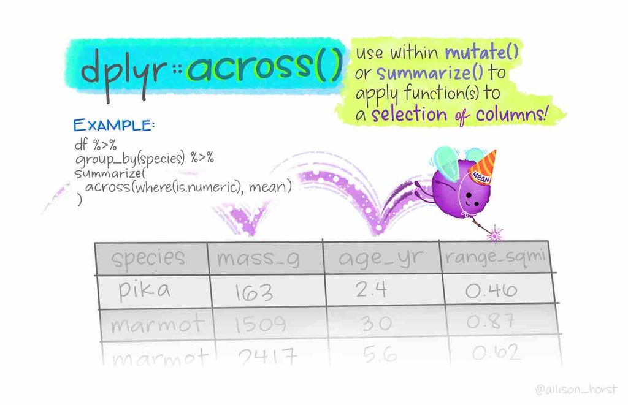

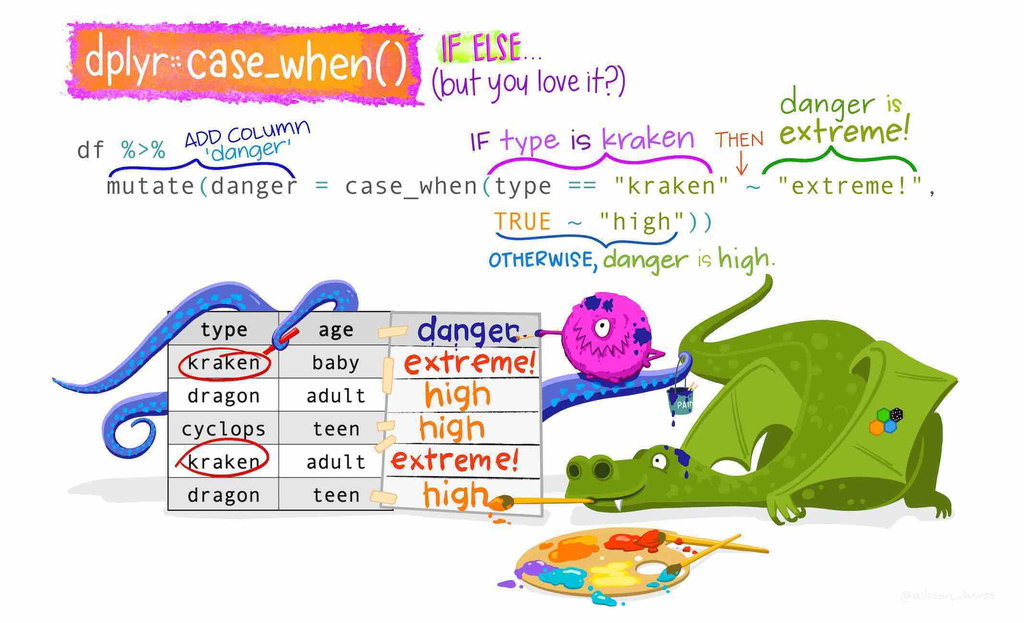

## [Il y a tellement d’autres fonctions !](https://www.rstudio.com/wp-content/uploads/2015/02/data-wrangling-cheatsheet.pdf)

[figure not shown]